# Grizzly Bear Analysis for the Kispiox Timber Supply Review

Tyler Muhly, Forest Analysis and Inventory Branch

25/11/2021

## Background

Grizzly bear (*Ursus arctos horribilus*) are an important part and indicator of diverse and resilient ecosystems. They occur throughout most of British Columbia, and the provincial government has committed to maintaining and conserving grizzly bear diversity and abundance throughout their range ([Ministry of Environment, Lands and Parks 1995](https://www2.gov.bc.ca/assets/gov/environment/plants-animals-and-ecosystems/wildlife-wildlife-habitat/grizzly-bears/futureforgrizzly1995.pdf)). They are a a species of high management and conservation interest to Indigenous, provincial and federal levels of government.

### Importance to the Canadian Government

The Committee on the Status of Endangered Wildlife in Canada (COSEWIC) lists grizzly bear as a species of [*Special Concern*](https://wildlife-species.canada.ca/species-risk-registry/species/speciesDetails_e.cfm?sid=1195) in Canada because of their poor condition in some parts of their range, low reproductive rates and increasing pressures from resource extraction and cumulative effects on their habitat.

Under the federal *Species at Risk Act* they are listed as [*Schedule 1, Special Concern*](https://wildlife-species.canada.ca/species-risk-registry/species/speciesDetails_e.cfm?sid=1195), meaning they *may* become threatened or endangered because of their biological characteristics and identified threats.

### Importance to the British Columbian Government

In British Columbia, grizzly bear are [*blue listed*](https://www2.gov.bc.ca/gov/content/environment/plants-animals-ecosystems/conservation-data-centre/explore-cdc-data/red-blue-yellow-lists), meaning they are at risk, but not extirpated, endangered or threatened. They have an [S3](https://www2.gov.bc.ca/gov/content/environment/plants-animals-ecosystems/conservation-data-centre/explore-cdc-data/status-ranks) conservation status, meaning they are vulnerable due to a restricted range, relatively few populations, recent and widespread declines, or other factors.

### Importance to First Nations Governments

Grizzly bear are culturally important species to the the Skeena First Nations (Lake Babine Nation, Office of the Wet’suwet’en, Gitxsan Nation, Gitanyow Nation, Wet’suwet’en First Nation, Witset (Moricetown), NeeTahi-Buhn, Skin Tyee, Hagwilget Village, and Gitwangak). The following excerpt from the [Skeena Sustainability Assessment Forum’s State of Value Report for Grizzly Bear](https://www2.gov.bc.ca/gov/content/environment/natural-resource-stewardship/cumulative-effects-framework/regional-assessments/skeena) describes the importance of grizzly bear to the Skeena First Nations:

*“There has always been a deep respect for grizzly bears; they are sacred animals. Traditionally they hold a very important spiritual significance in our teachings and we would use their grease, fat, and claws. We would never hunt grizzly bear for food and know to never go to the wild celery area because that is where grizzly bears give birth. It is considered taboo to talk about or mock them because they know what you are saying if you talk about them. Grizzly bears were also used in storytelling, but the stories are not killing them because when ancestors tried to kill and cook the grizzly it turned into a cloud of mosquitos and that is where mosquitos came from. Grizzly bears hold a spiritual significance for teaching younger generations and as such, deep respect is shown to them.”*

### Conservation Status of Grizzly Bear in the Kispiox TSA

The Kispiox TSA overlaps portions of the Babine, Bulkley-Lakes and Cranberry grizzly bear population units (GBPUs). GBPUs are provincial administrative areas used to describe grizzly bear population abundance and stability, and for assessing regional and sub-regional variation in populations and habitats.

The Babine GBPU has a conservation status of M3 (medium concern, due to high mortality and human presence). It has relatively high road densities and some areas consist of sub-optimal mid seral dense conifer forest. The Bulkley-Lakes GBPU is also M3 (but due to isolation and proximity to communities and highways), and has high mortality risk. The Cranberry GBPU has a conservation status of M4 (low concern, due to limited industrial development and access).

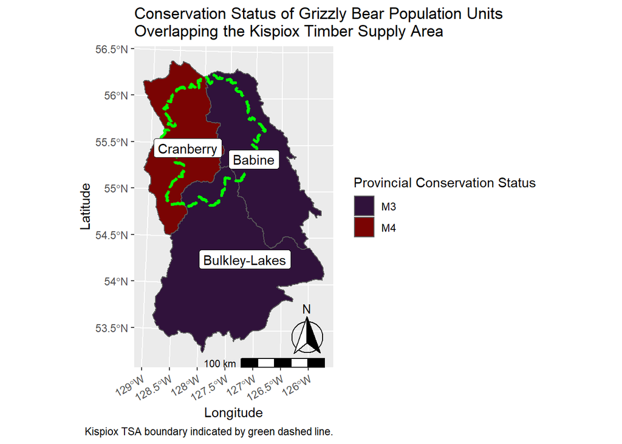

## Relationship to Forestry

Grizzly bears may be negatively impacted by forestry activity, due to development of roads, or if forest harvest does not provide a diversity of stand ages within a landscape.

### Roads

Roads are the greatest threat to grizzly bear, and negatively correlate strongly with grizzly bear survival and habitat quality ([Skeena Sustainability Assessment Forum’s State of Value Report for Grizzly Bear](https://www2.gov.bc.ca/assets/gov/environment/natural-resource-stewardship/cumulative-effects/skeena-region/ssaf_grizzly_bear_state_of_the_value_report_sept2020_final.pdf)). For example, most grizzly bear deaths occur within 500 m of a road or other linear corridor, due to human-bear conflicts, poaching or collisions with vehicles. A road density of 0.31 to 0.60 km/km<sup>2</sup> within a landscape unit is considered moderate risk, and a road density of 0.61 to 0.75 km/km<sup>2</sup> is considered high risk to grizzly bear.

### Forest Stand Characteristics

Middle aged (mid-seral) conifer forest stands (i.e., stands between 40 to 100 years old) are considered poor habitat for grizzly bear, as they typically are closed-canopy and thus provide little forage value (i.e., food plants, such as huckleberries). The amount of mid-seral conifer forest stands within Coastal Western Hemlock (CWH), Interior Cedar Hemlock (ICH) and Sub-Boreal Spruce (SBS) zones within landscape units can be used as an indicator of the amount of sub-optimal habitat for grizzly bear ([Skeena Sustainability Assessment Forum’s State of Value Report for Grizzly Bear](https://www2.gov.bc.ca/assets/gov/environment/natural-resource-stewardship/cumulative-effects/skeena-region/ssaf_grizzly_bear_state_of_the_value_report_sept2020_final.pdf)).

## Current Conditions

There are few legal grizzly bear habitat designations in the Kispiox TSA. Wildlife habitat area (WHA) [6-055](https://www.env.gov.bc.ca/wld/documents/wha/URAR_6-055_ord.pdf) designates some no harvest and conditional harvest areas in approximately 1,050 ha of the Babine GBPU to minimize road development there. Land and resource management plans for the Skeena, and the Gitanyow Huwilp Recognition and Reconciliation Agreement direct natural resource operations to maintain and provide adequate habitat for grizzly bear populations in the region ([Skeena Sustainability Assessment Forum’s State of Value Report for Grizzly Bear](https://www2.gov.bc.ca/assets/gov/environment/natural-resource-stewardship/cumulative-effects/skeena-region/ssaf_grizzly_bear_state_of_the_value_report_sept2020_final.pdf)). There are also silvicultural guidelines for the CWH zone to plant stands in a clustered, rather than even-spaced distribution and thus maintain some open canopy in forest stands to support the production of grizzly bear forage.

### Population Status and Trend

Grizzly bear populations in the region appear to be healthy. The Babine GBPU has a population estimate of 313 animals, and a density of 23 bears/1,000km<sup>2</sup>. The Bulkley-Lakes GBPU has a population estimate of 439 animals, and a density of 20 bears/1,000km<sup>2</sup>. The Cranberry GBPU has a population estimate of 352 animals, and a density of 31 bears/1,000km<sup>2</sup>. All of the GBPUs are well above the 10 bears/1,000km<sup>2</sup> threshold that would put them at higher risk. However, the [previous cumulative effects assessment](https://www2.gov.bc.ca/assets/gov/environment/natural-resource-stewardship/cumulative-effects/skeena-region/ssaf_grizzly_bear_state_of_the_value_report_sept2020_final.pdf) found that some LUs within the Bulkley-Lakes and Babine GBPUs were between 10-20 bears per 1000 km<sup>2</sup>.

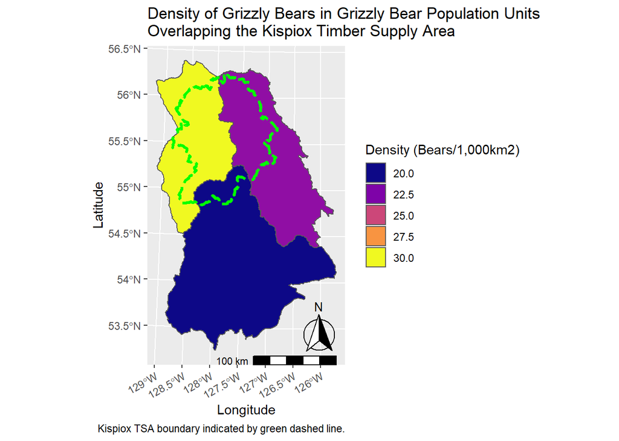

Adult female grizzly bear mortality rates are relatively low (<2%) in the GBPUs that overlap the Kispiox TSA, but mortality rates are relatively high (2-3%) in some LUs in the Babine GBPU, in the southeast portion of the Kispiox TSA. However, these data pre-date the recent provincial ban on grizzly bear hunting, which made up 72% of mortalities in the region.

### Roads

Road densities are relatively high in the Kispiox TSA, with 6 of the 10 landscape untis havign road densitives greater than 0.6 km/km^2.

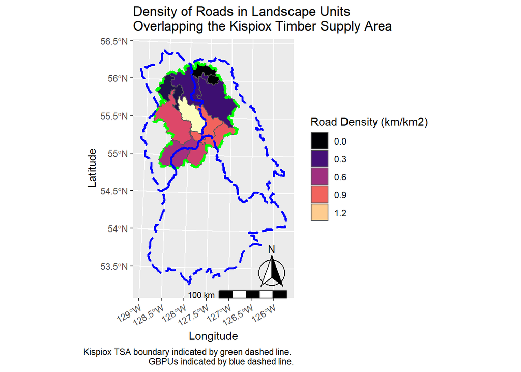

### Forest Stand Characteristics

All landscape units within the Kispiox TSA have a percent mid-seral (age 40 to 100) conifer forest in CWH, ICH and SBS well below 30%. This suggests that vegetation forage availability is adequate in the region. The Cranberry landscape unit on the western side of the TSA had the most mid-seral conifer forest (8%.)

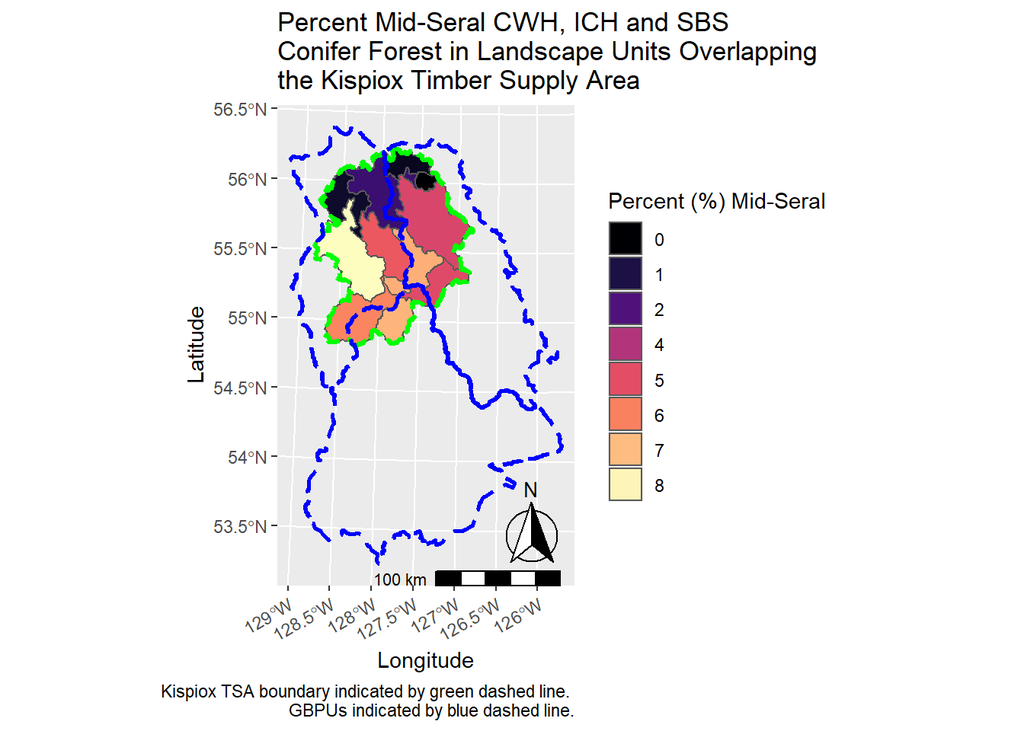

## Future Conditions

- analyze outputs from timber supply models, if/when available

### Alternate Forest Management Regimes for Grizzly Bear

- is there a grizzly bear focused scenario we could analyze?

### Forest Stand Characteristics

## Mitigating Potential Impacts of Forest Harvest to Grizzly Bear

Impacts to grizzly bear from forestry can be mitigated by limiting road building and deactivating and restoring roads that are built, particularly in high quality grizzly bear habitat. This will mitigate grizzly bear mortality risks by reducing potential for human-grizzly bear interactions.

Maintaining a distribution of young (<40 years old) and old (>100 years old) forest stands will help support adequate forage vegetation for grizzly bear. Significant fluctuations in forest harvest trends (i.e., large peaks and valleys in the amount of area harvested) should be avoided to prevent the landscape from ultimately being dominated by mid-seral forest.

## Uncertainties and Limitations

Grizzly bear population estimates were calculated from a provincial model ([Mowat et al. 2013](https://journals.plos.org/plosone/article?id=10.1371/journal.pone.0082757)) rather than local data, and thus uncertainty around the estimate is relatively high. Monitoring projects using grizzly bear hair-snares to estimate population abundance from DNA have recently been implemented by the Gitanyow First Nation, Office of the Wet’suwet’en and the Gitxsan Nation.